# ML Classification

Applied Machine Learning in Economics

We have done it! We have finally made it to the point in the semester where we will be talking about techniques that don’t show up in the standard econometric textbook!

# 1 Preliminaries

Packages and data!

```r
# packages that make us cheery
library(tidyverse)
library(caret)   # confusionMatrix
```

```r
library(plotROC) # geom_roc()
library(class)   # knn()
library(MASS)    # lda(), qda()
# Loading the data
ahs = read.csv('C:/Users/johnj/Documents/Data/Applied ML ECON490/Lecture Data/lecture data discrete.csv')
load('C:/Users/johnj/Documents/Data/Applied ML ECON490/Lecture Data/logistic fit.rda')

# Sample-splitting
set.seed(490)
train = ahs %>% sample_frac(0.75)
test = anti_join(ahs, train, by = 'id')
```

# 2 Diagnostics

We have seen how to interpret two classification diagnostics. But how do we generate them?

## 2.1 Confusion Matrix

Recall that the confusion matrix represents the (mis)classifications from our model. The diagonal elements are correct predictions and the off diagonal are incorrect predictions.

Starting with the logistic regression:

```r
b_yhat = ifelse(predict(bfit, test, type = 'response') > 0.5,
              TRUE,
              F)

confusionMatrix(as.factor(b_yhat), as.factor(test$renter))
```

```
## Confusion Matrix and Statistics
##
##           Reference
## Prediction FALSE TRUE
##      FALSE  2226  305
##      TRUE    161 1179
##
##                Accuracy : 0.8796
##                  95% CI : (0.869, 0.8897)
##     No Information Rate : 0.6166
##     P-Value [Acc > NIR] : < 2.2e-16
##
##                   Kappa : 0.7406
##
##  Mcnemar's Test P-Value : 3.488e-11
##
##             Sensitivity : 0.9326
##             Specificity : 0.7945
##          Pos Pred Value : 0.8795
##          Neg Pred Value : 0.8799
##              Prevalence : 0.6166
##          Detection Rate : 0.5750
##    Detection Prevalence : 0.6538
##       Balanced Accuracy : 0.8635
##
##        'Positive' Class : FALSE
##
```

This gives us a lot of information that could be useful on determining which model would be best suited for our application. Looking down the columns of the confusion matrix, it appears that we are better at predicting non-rented units (owned) than rented units.

What about for our multinomial case?

```r
m_yhat = predict(mfit, test, type = 'class')
confusionMatrix(m_yhat, as.factor(test$npeople))
```

```
## Confusion Matrix and Statistics
##
##           Reference
## Prediction    1    2    3
##          1 1022  424   95
##          2  532 1130  512
##          3   20   59   77
##
## Overall Statistics
##
##                Accuracy : 0.5758
##                  95% CI : (0.5601, 0.5915)
##     No Information Rate : 0.4167
##     P-Value [Acc > NIR] : < 2.2e-16
##
##                   Kappa : 0.2895
##
##  Mcnemar's Test P-Value : < 2.2e-16
##
## Statistics by Class:
##
##                      Class: 1 Class: 2 Class: 3
## Sensitivity            0.6493   0.7006  0.11257
## Specificity            0.7741   0.5376  0.97521
## Pos Pred Value         0.6632   0.5198  0.49359
## Neg Pred Value         0.7631   0.7154  0.83661
## Prevalence             0.4066   0.4167  0.17670
## Detection Rate         0.2640   0.2919  0.01989
## Detection Prevalence   0.3981   0.5616  0.04030
## Balanced Accuracy      0.7117   0.6191  0.54389
```

This model does a moderately okay job predicting one occupant or two occupant units, but it really struggles with three-plus occupancy. It is informative to look at this table, because perhaps we are less interested in predicting that group.

But if there is only one group that we are interested in, then why aren’t we using binomial logistic regression on an indicator variable for said group of interest?

## 2.2 ROC

The ROC curve is really only applicable for a binary response variable: a yes or no. You can bend the ROC curve for the $>2$ class case, but then you are comparing one group to all groups. The interpretation and implementation from the results are messy and convoluted.

In short, ROC for binary response.

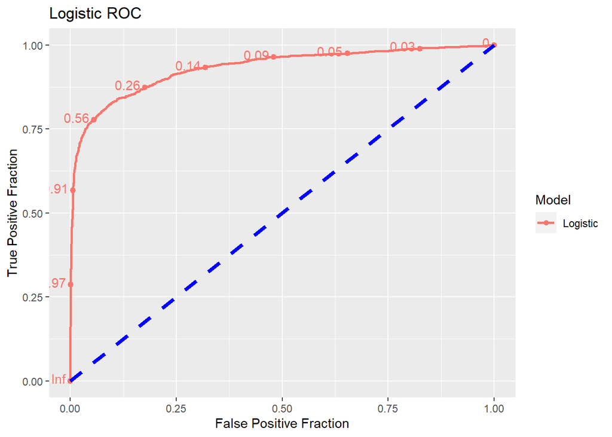

```r
b_yhat = predict(bfit, test, type = 'response')
dfb = data.frame(yhat = b_yhat, y = test$renter, model = 'Logistic')

ggplot(dfb, aes(m = yhat, d = y, color = model))  +
  geom_roc(n.cuts = 10, labelround = 2) +
  labs(title = 'Logistic ROC', x = 'False Positive Fraction', y = 'True Positive Fraction') +
  scale_color_discrete(name = 'Model') +
  geom_segment(aes(x = 0, y = 0, xend = 1, yend = 1), color = 'blue', linetype = 'dashed', size = 1.5)
```

From here we see that the threshold value of 0.56 appears to be doing a good job! The dashed blue line would be the result if we were just randomly guessing.

We can use the `ggplot` object to create an interactive plot and calculate the area under the curve (AUC).

```r
roc = ggplot(dfb, aes(m = yhat, d = y*1, color = ''))  +
  geom_roc(n.cuts = 10, labelround = 2)  +
  labs(title = 'Logistic ROC', x = 'False Positive Fraction', y = 'True Positive Fraction') +
  theme(text = element_text(size = 20)) +
  scale_color_discrete(name = 'Model')
```

Because we are in a markdown environment, the interactive plot won’t knit to `.html`, but you should explore this in a regular `.R` script.

Here is the code: `plot_interactive_roc(roc, labelround = 2)`

Finally, we calculate the AUC by using a trivially simple single line of code! How convenient!

```r
calc_auc(roc)
```

```
##   PANEL group       AUC
## 1     1     1 0.9319207
```

That seems pretty good to me! But the AUC really comes in handy where we have multiple models to compare across.

We could end up in a situation that easy to predict, which means all models are relatively high. OR, we could be in a situation that is challenging to predict, which means all models will have a low AUC.

**IMPORTANT:** Whenever predicting classes, it is always a good idea to compare the performance of your model(s) to randomly guessing. If you aren’t doing much better than just guessing one group over and over again, then you need to go back to the model selection stage.

# 3 KNN

The inputs for the `knn` function are a bit picky. Instead of inputting `data.frame`s (or `tibble`s), we need to put in the matrix of $X$ variables for training and testing, alongside the $y$ for training.

We can obtain them as follows:

```r
x_train = model.matrix(mfit)
x_test  = model.matrix(fm, data = test)
y_train = train$npeople
```

We also need to specify the number of nearest neighbors we want to use. Let’s start off with four and see what the accuracy is (accuracy = 1 - error rate).

```r
kfit = knn(x_train, x_test, y_train, 4)
mean(kfit == test$npeople)
```

```
## [1] 0.522604
```

Not that great.

Let’s see if we need a different value of `k`.

```r
K = c(2:6, 10, 15, 20, 30, 50, 100)
for(k in K){
  kfit = knn(x_train, x_test, y_train, k)
  accuracy = mean(kfit == test$npeople)
  cat('k =', k, '   Accuracy =', accuracy, '\n')
}
```

```
## k = 2    Accuracy = 0.4866959
## k = 3    Accuracy = 0.5122707
## k = 4    Accuracy = 0.5288039
## k = 5    Accuracy = 0.5342289
## k = 6    Accuracy = 0.5466288
## k = 10    Accuracy = 0.5455955
## k = 15    Accuracy = 0.5453371
## k = 20    Accuracy = 0.5499871
## k = 30    Accuracy = 0.5502454
## k = 50    Accuracy = 0.5528287
## k = 100    Accuracy = 0.5468871
```

It looks like somewhere around 50 nearest neighbors produces the most accurate model.

Let’s save this model for comparison later on.

```r
kfit = knn(x_train, x_test, y_train, 50)
```

Here is another way that we can produce a confusion matrix:

```r
table(kfit, test$npeople)
```

```
##
## kfit    1    2    3
##    1  935  418  106
##    2  622 1111  482
##    3   17   84   96
```

# 4 LDA

The function `lda` for linear discriminant analysis is a lot simpler to use; it doesn’t nest the predictions inside the fit (which may be a feature you prefer).

```r
ldafit = lda(fm, train)
ldafit
```

```
## Call:
## lda(fm, data = train)
##
## Prior probabilities of groups:
##         1         2         3
## 0.3940072 0.4303427 0.1756501
##
## Group means:
##   log(cost)   hoaTRUE log(hinc)     beds    baths   lotsize      yos  condoTRUE
## 1  6.815177 0.2443182  10.27123 2.027098 1.498361 0.2943209 13.99017 0.15974650
## 2  7.126122 0.3109244  11.13574 2.800720 1.944778 0.5851341 15.23189 0.10064026
## 3  7.254370 0.2916667  11.37329 3.290686 2.090686 0.4796569 15.24853 0.06127451
##   garageTRUE bldApt >= 10 bldAttached SFH bldDetached SFH bldMobile Home
## 1  0.4576049   0.36298077       0.1086101       0.3435315     0.02032343
## 2  0.6634654   0.16666667       0.1020408       0.6136455     0.02320928
## 3  0.6808824   0.08235294       0.1024510       0.7004902     0.01519608
##      crime     hinf    houtf log(cost):hoaTRUE beds:baths
## 1 407.5848 6.379787 8.689263          1.715467   3.498689
## 2 406.2075 6.524328 8.793282          2.262743   5.966487
## 3 408.5822 6.408433 8.732692          2.154616   7.292157
##
## Coefficients of linear discriminants:
##                             LD1          LD2
## log(cost)          0.1119099336  0.179961535
## hoaTRUE            0.7204111213  0.849163836
## log(hinc)          0.4870850465 -0.135777937
## beds               1.0398975281  0.350670345
## baths              0.7601160531 -1.603127014
## lotsize            0.0051460440 -0.245213661
## yos                0.0274446149 -0.132579363
## condoTRUE         -0.3614809651  0.154742529
## garageTRUE        -0.2390034495 -0.431125693
## bldApt >= 10      -0.1370659389 -0.243515329
## bldAttached SFH   -0.2234846971 -0.453961547
## bldDetached SFH   -0.0558843721 -1.051555083
## bldMobile Home    -0.0170794263 -1.233938111
## crime             -0.0006975348  0.002475125
## hinf               0.0589632016 -0.492386796
## houtf             -0.1095911011  0.429969442
## log(cost):hoaTRUE -0.1088738679 -0.174133627
## beds:baths        -0.2318447354  0.379816536
##
## Proportion of trace:
##    LD1    LD2
## 0.9365 0.0635
```

The output shows us the coefficients on the linear discrimination boundaries. See the textbook for more details.

Now we can evaluate how this model performed.

```r
ldahat = predict(ldafit, test)

# Confusion Matrix
table(ldahat$class, test$npeople)
```

```
##
##        1    2    3
##   1  992  402   85
##   2  563 1141  514
##   3   19   70   85
```

```r
# Accuracy
mean(ldahat$class == test$npeople)
```

```
## [1] 0.5729786
```

Looks like LDA has done slightly better than KNN.

# 5 QDA

QDA follows similarly. What was the difference between LDA and QDA again?

```r
# Fitting the model
qdafit = qda(fm, train)
qdafit
```

```
## Call:
## qda(fm, data = train)
##
## Prior probabilities of groups:
##         1         2         3
## 0.3940072 0.4303427 0.1756501
##
## Group means:
##   log(cost)   hoaTRUE log(hinc)     beds    baths   lotsize      yos  condoTRUE
## 1  6.815177 0.2443182  10.27123 2.027098 1.498361 0.2943209 13.99017 0.15974650
## 2  7.126122 0.3109244  11.13574 2.800720 1.944778 0.5851341 15.23189 0.10064026
## 3  7.254370 0.2916667  11.37329 3.290686 2.090686 0.4796569 15.24853 0.06127451
##   garageTRUE bldApt >= 10 bldAttached SFH bldDetached SFH bldMobile Home
## 1  0.4576049   0.36298077       0.1086101       0.3435315     0.02032343
## 2  0.6634654   0.16666667       0.1020408       0.6136455     0.02320928
## 3  0.6808824   0.08235294       0.1024510       0.7004902     0.01519608
##      crime     hinf    houtf log(cost):hoaTRUE beds:baths
## 1 407.5848 6.379787 8.689263          1.715467   3.498689
## 2 406.2075 6.524328 8.793282          2.262743   5.966487
## 3 408.5822 6.408433 8.732692          2.154616   7.292157
```

```r
# Predictions
qdahat = predict(qdafit, test)

# Confusion matrix
table(qdahat$class, test$npeople)
```

```
##
##        1    2    3
##   1 1067  539  149
##   2  300  534  155
##   3  207  540  380
```

```r
mean(qdahat$class == test$npeople)
```

```
## [1] 0.5117541
```

# 6 Model Comparisons

## 6.1 Multiple classes

For the multiclass comparisons, we must rely on a summary statistic. Let’s use the error rate.

```r
cat('KNN error rate:', mean(kfit != test$npeople))
```

```
## KNN error rate: 0.4466546
```

```r
cat('Multinomial error rate:', mean(predict(mfit, test, type = 'class') != test$npeople))
```

```
## Multinomial error rate: 0.4241798
```

```r
cat('LDA error rate:', mean(ldahat$class != test$npeople))
```

```
## LDA error rate: 0.4270214
```

```r
cat('QDA error rate:', mean(qdahat$class != test$npeople))
```

```
## QDA error rate: 0.4882459
```

It appears the multinomial logistic regression is the best performing model!

## 6.2 One Class

Now that we are coming back to the ROC and AUC. This will require some setup.

Think about why I am doing what in the code chunk below

```r
#######################
# Logistic Regression #
#######################
b_yhat = predict(bfit, test, type = 'response')
dfb = data.frame(yhat = b_yhat, y = test$renter, model = 'Logistic')


#######
# KNN #
#######
x_train = model.matrix(bfit)
x_test  = model.matrix(fb, data = test)
y_train = train$renter

kfit = knn(x_train, x_test, y_train, 4)
mean(kfit == test$renter)
```

```
## [1] 0.8406097
```

```r
K = c(2:6, 10, 15, 20, 30, 50, 100)
for(k in K){
  kfit = knn(x_train, x_test, y_train, k)
  accuracy = mean(kfit == test$renter)
  cat('k =', k, '   Accuracy =', accuracy, '\n')
}
```

```
## k = 2    Accuracy = 0.8127099
## k = 3    Accuracy = 0.8493929
## k = 4    Accuracy = 0.8483596
## k = 5    Accuracy = 0.8530096
## k = 6    Accuracy = 0.8563679
## k = 10    Accuracy = 0.8524929
## k = 15    Accuracy = 0.8563679
## k = 20    Accuracy = 0.8558512
## k = 30    Accuracy = 0.8514596
## k = 50    Accuracy = 0.8493929
## k = 100    Accuracy = 0.8357014
```

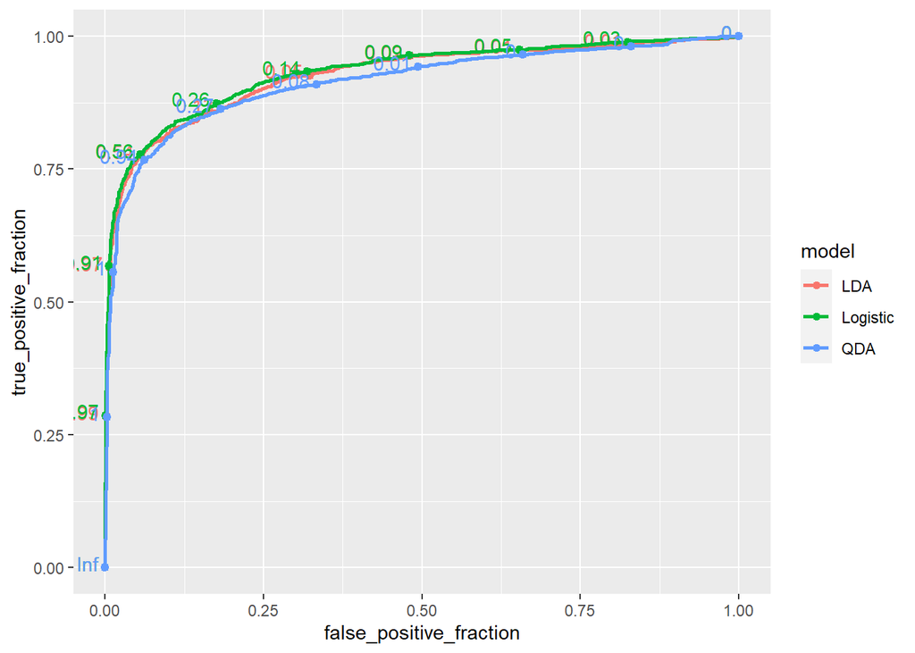

```r
kfit = knn(x_train, x_test, y_train, 15)
dfk = tibble(yhat = kfit, y = test$renter, model = 'KNN')

#######
# LDA #
#######
ldafit = lda(fb, train)
ldahat = predict(ldafit, test)

dflda = tibble(yhat = ldahat$posterior[,2], y = test$renter, model = 'LDA')


#######
# QDA #
#######
qdafit = qda(fb, train)
qdahat = predict(qdafit, test)

dfqda = tibble(yhat = qdahat$posterior[,2], y = test$renter, model = 'QDA')

#######
# ROC #
#######
df = bind_rows(dfb, dflda, dfqda)
# can't plot knn, because knn predicts classes, not probabilities

(final = ggplot(df, aes(m = yhat, d = y, color = model)) +
  geom_roc(n.cuts = 10, labelround = 2) )
```

```r
calc_auc(final)
```

```
##   PANEL group       AUC
## 1     1     1 0.9269586
## 2     1     2 0.9319207
## 3     1     3 0.9142548
```

```r
mean(ldahat$class == test$renter)
```

```
## [1] 0.878326
```

```r
mean(kfit == test$renter)
```

```
## [1] 0.8563679
```

# 7 Concluding Thoughts

We have just shown that different techniques can outperform one another in different situations. To give us more of an idea of where we would expect these models to do well, read the three pages of chapter 4.5.